# ReporteLab2

2022-08-02

## Analisis exploratorio de Importaciones

Para las importaciones se tienen los siguientes datos:

```r
data_impor
```

```
## # A tibble: 257 x 6
##    Fecha               Superior Regular  Diesel Total_Gasolinas Total_Importaci~
##    <dttm>                 <dbl>   <dbl>   <dbl>           <dbl>            <dbl>
##  1 2001-01-01 00:00:00  373964. 177776. 566102.         551740.         2312639.
##  2 2001-02-01 00:00:00  243091. 123116. 489526.         366207.         1769209.
##  3 2001-03-01 00:00:00  312084. 161726. 575560.         473811.         1945770.
##  4 2001-04-01 00:00:00  285055. 127339. 437745.         412394.         1623638.
##  5 2001-05-01 00:00:00  300914. 168730. 552609.         469644.         2262727.
##  6 2001-06-01 00:00:00  333217. 152899. 497855.         486116.         1824277.
##  7 2001-07-01 00:00:00  195072. 136299. 302350.         331371.         1394478.
##  8 2001-08-01 00:00:00  268153. 139365. 464159.         407518.         1972910.
##  9 2001-09-01 00:00:00  308439. 233644. 321953.         542083.         1844365.
## 10 2001-10-01 00:00:00  305102. 141550. 438990.         446652.         2035584.
## # ... with 247 more rows
```

de los mismos se pueden obtener lo siguente:

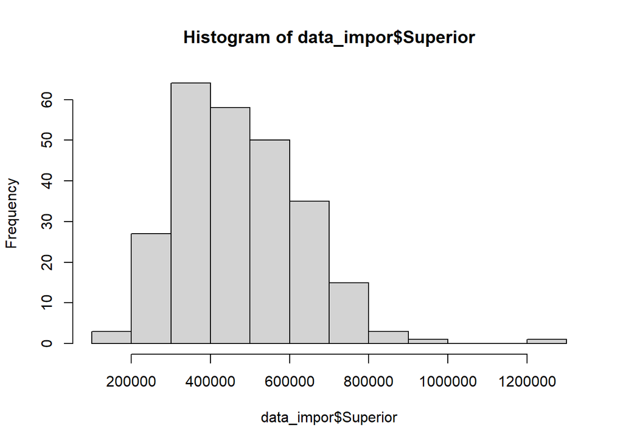

```r
hist(x = data_impor$Superior)
```

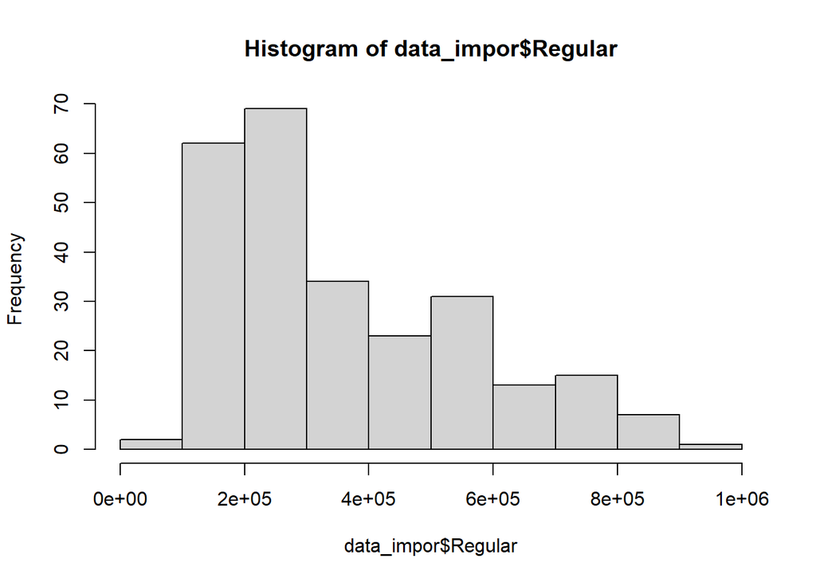

```r
hist(x = data_impor$Regular)
```

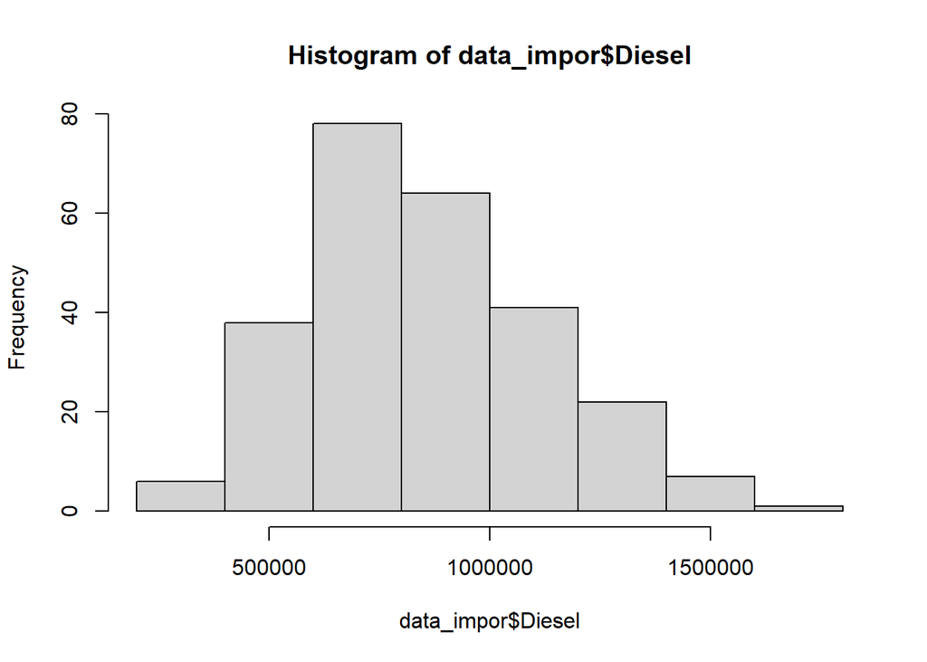

```r
hist(x = data_impor$Diesel)
```

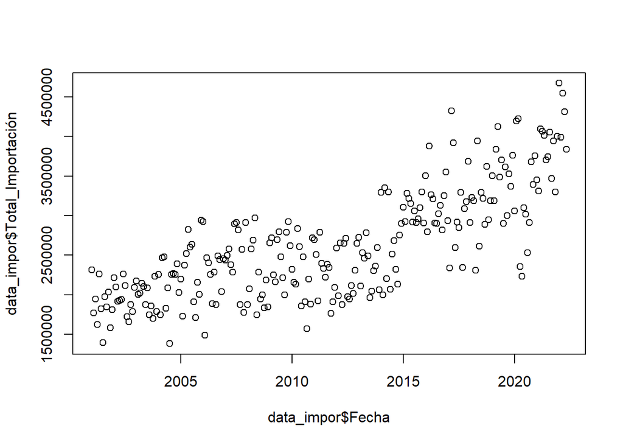

```r
plot(data_impor$Fecha, data_impor$Total_Importación)
```

Ahora, explorando aun mas los datos, podemos ver cuales han sido las fechas en las que se encuentra una mayor importacion por cada uno de los tipos de combustible.

Para el combustible superior:

```r
super
```

```
## # A tibble: 10 x 2
##    Fecha               Superior
##    <dttm>                 <dbl>
##  1 2021-04-01 00:00:00 1227174.
##  2 2022-01-01 00:00:00  947208.
##  3 2021-03-01 00:00:00  850335.
##  4 2020-03-01 00:00:00  809640.
##  5 2017-12-01 00:00:00  803217.
##  6 2019-12-01 00:00:00  797581.
##  7 2018-07-01 00:00:00  784602.
##  8 2020-12-01 00:00:00  777451.
##  9 2016-03-01 00:00:00  771024.
## 10 2017-07-01 00:00:00  769214.
```

Para el combustible regular:

```r
regu
```

[output not shown]

Para el combustible diesel:

```r
dies
```

[output not shown]

Asi mismo podemos ver cuales fueron las fechas en las que se observa una cantidad menor de importacion de cada uno de los tipos de combustible.

```r
menossuper
```

```
## # A tibble: 10 x 2
##    Fecha               Superior
##    <dttm>                 <dbl>
##  1 2020-05-01 00:00:00  170292.
##  2 2005-09-01 00:00:00  193484.
##  3 2001-07-01 00:00:00  195072.
##  4 2007-04-01 00:00:00  203441.
##  5 2008-01-01 00:00:00  204788.
##  6 2010-11-01 00:00:00  241063.
##  7 2008-08-01 00:00:00  241881.
##  8 2001-02-01 00:00:00  243091.
##  9 2002-03-01 00:00:00  246293.
## 10 2004-07-01 00:00:00  249711.
```

Para el combustible regular:

```r
menosregu
```

[output not shown]

Para el combustible diesel:

```r
menosdies
```

[output not shown]

Graficas:

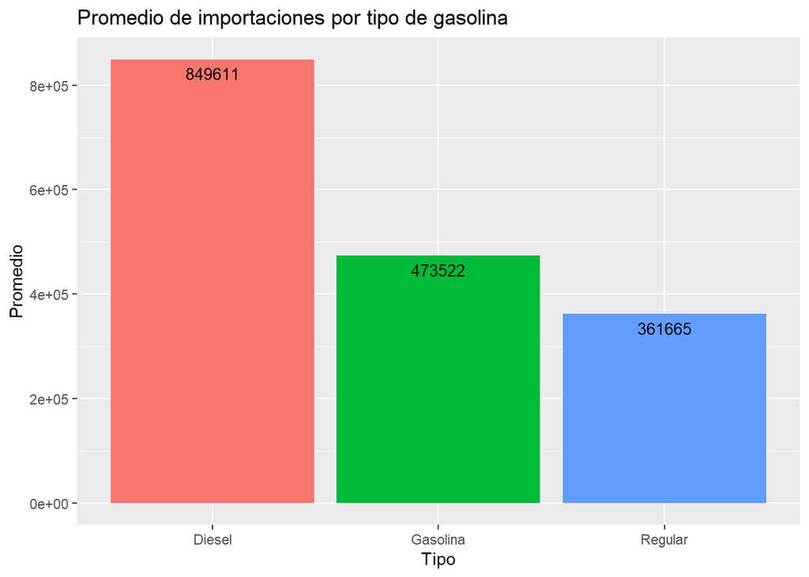

```r
grafdef
```

Como se observa en la grafica se puede ver que la gasolina Diesel ha sido la que mayor importaciones ha tenido en promedio, lo cual es de cierta forma algo logico, debido a que este combustible juega un papel importante en el transporte publico y pesado, sin tomar en cuenta la gran cantidad de vehiculos y maquinas que se manejan con ese combustible.

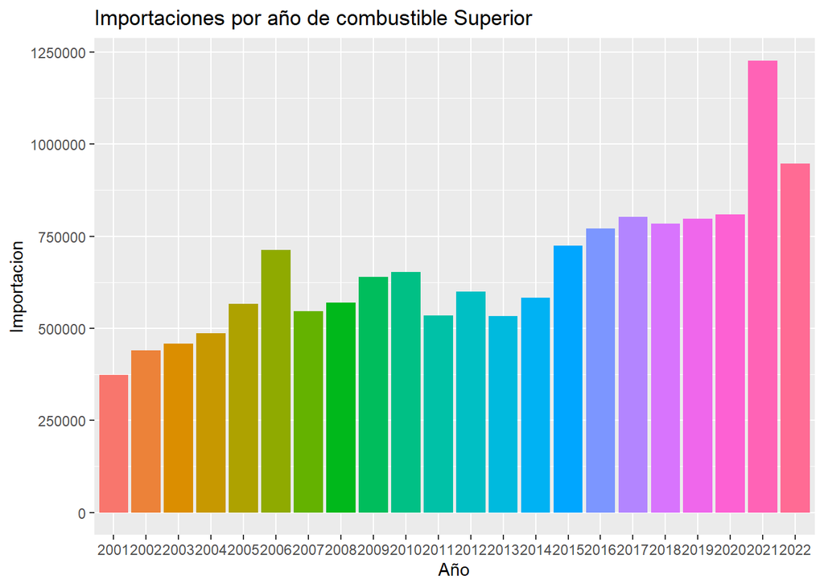

```r
grafsup
```

Y basados en la grafica anterior, podemos ver que el año 2021 fue el año con que el combustible super cuenta con mayor cantidad de importacion reportada.

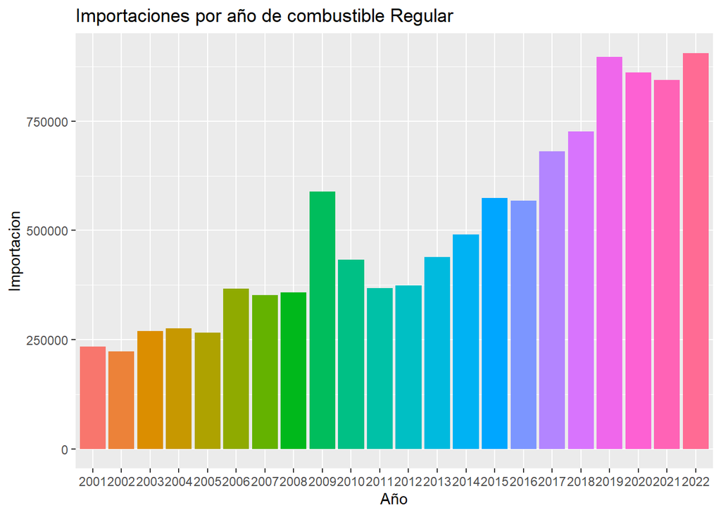

```r
grafreg
```

Como podemos ver, el año 2022 es el cual se lleva reportado una mayor cantidad de combustible Regular, lo cual de cierta forma podemos decir que es equivalente a lo que se vio, debido al alza de los precios, el combustible Superior presentaba un valor mas caro que el Regular, por lo que la poblacion empezo a optar por esa opcion.

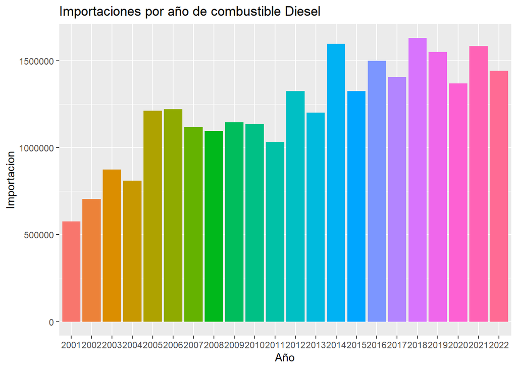

```r
grafdie
```

El 2018 fue el año que mayor cantidad de importaciones se han registrado.

## Series de las importaciones

Empezaremos con la serie del combustible Superior, como queremos hacer un modelo ARIMA dividiremos este proceso en cuatro pasos, los cuales seran iguales para todos los combustibles.

## Combustible SUPERIOR:

Primer paso, identificacion:

```r
# Para el combustible Superior
super_ts <- ts( super$`Superior`, start = c(2001,1),frequency = 12)

# Inicio de la serie
start(super_ts)
```

```
## [1] 2001    1
```

```r
#Final de la serie
end(super_ts)
```

```
## [1] 2022    5
```

```r
#Frecuencia de la serie
frequency(super_ts)
```

```
## [1] 12
```

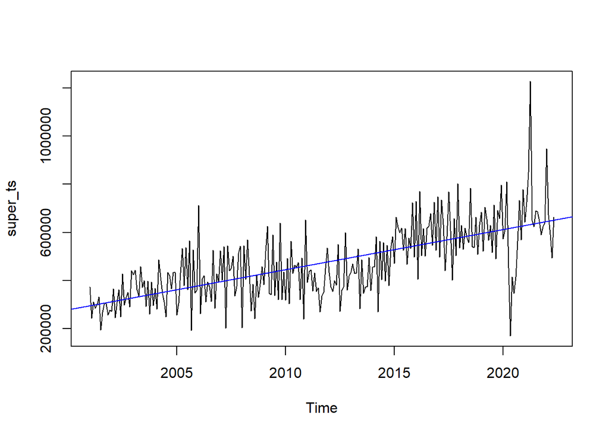

```r
#Resultado en forma de grafica.
plot(super_ts)
abline(reg=lm(super_ts~time(super_ts)), col=c("blue"))
```

Con esto, podemos ver el compartamiento que ha tenido el combustible superior a lo largo de los años.

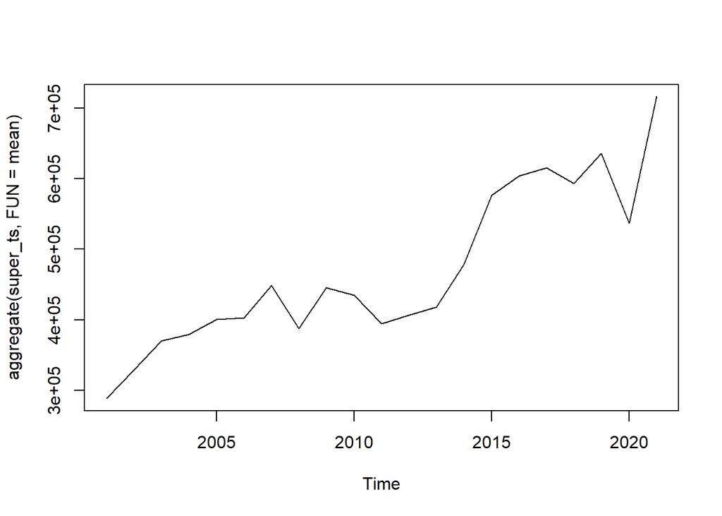

```r
plot(aggregate(super_ts,FUN=mean))
```

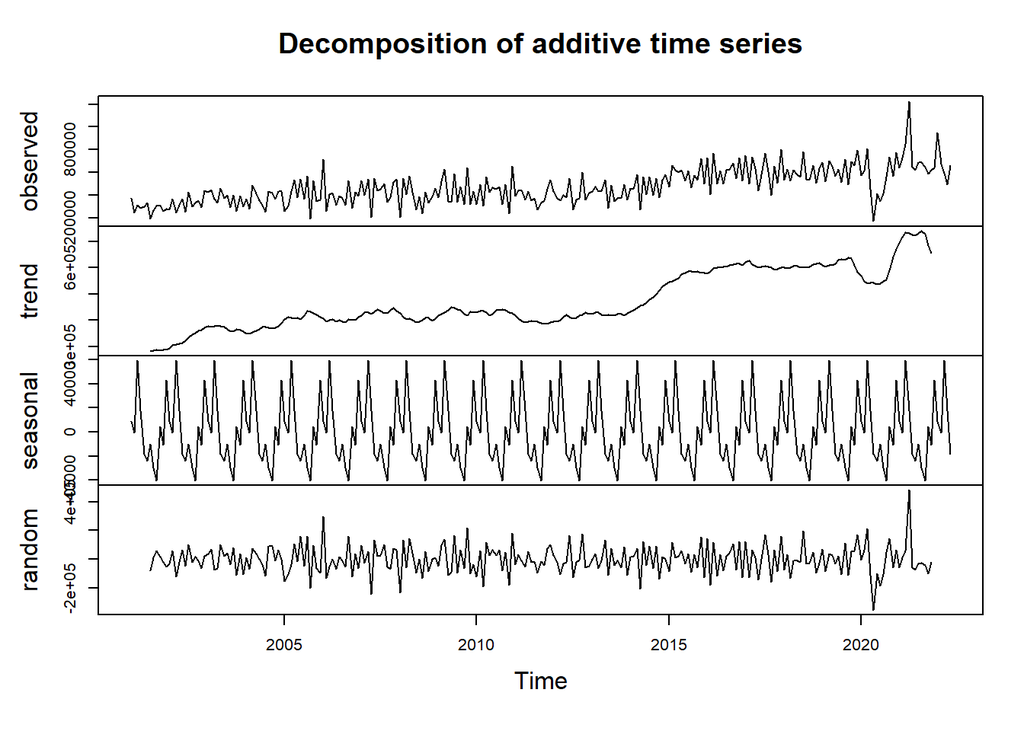

```r
dec.Super<-decompose(super_ts)
plot(dec.Super)
```

Como se observa en la grafica anterior, la serie tiene tendencia a aumentar asi como que tambien tiene estacionalidad y por ultimo, se puede ver que no es estacionaria en varianza, por eso debemos aplicarle una transformacion logaritmica.

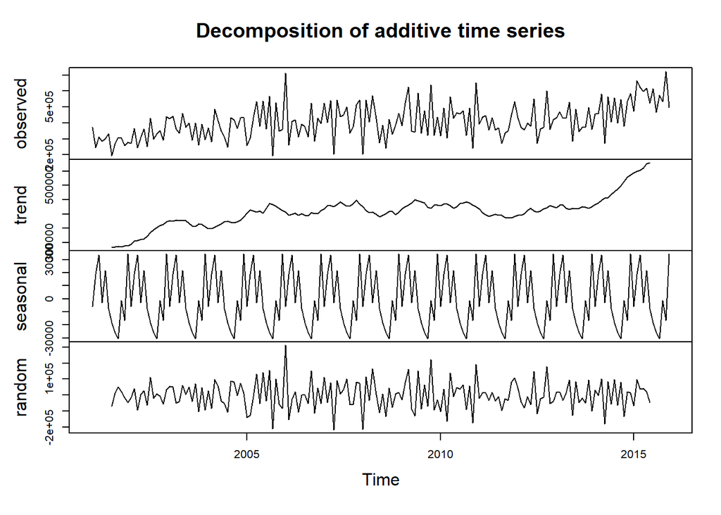

```r
train <- head(super_ts, round(length(super_ts) * 0.7))
h <- length(super_ts) - length(train)
test <- tail(super_ts, h)
#Aplicaremos una transformación logarítmica
Superlog <- log(train)
plot(decompose(train))
```

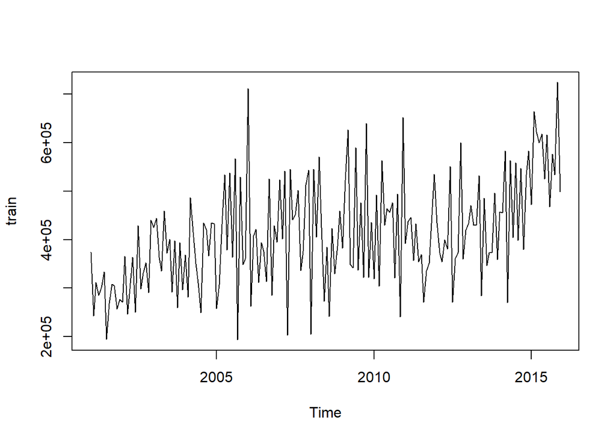

```r
#Ver el gráfico de la serie
plot(train)
```

Se observa con esta transformacion, se logro hacer constante en varianza, ahora podemos enfocarnos en su estacionalidad en la media, para eso haremos la prueba de raices…

```r
adfTest(train)
```

```
##
## Title:
##  Augmented Dickey-Fuller Test
##
## Test Results:
##   PARAMETER:
##     Lag Order: 1
##   STATISTIC:
##     Dickey-Fuller: -0.594
##   P VALUE:
##     0.4255
##
## Description:
##  Sun Aug 07 23:24:16 2022 by user: Quezada
```

```r
unitrootTest(train)
```

```
##
## Title:
##  Augmented Dickey-Fuller Test
##
## Test Results:
##   PARAMETER:
##     Lag Order: 1
##   STATISTIC:
##     DF: -0.594
##   P VALUE:
##     t: 0.4589
##     n: 0.5487
##
## Description:
##  Sun Aug 07 23:24:16 2022 by user: Quezada
```

El valor de P es mayor a 0.05, por lo que ahora veremos que pasa si le aplicamos una diferenciacion

```r
adfTest(diff(train))
```

```
##
## Title:
##  Augmented Dickey-Fuller Test
##
## Test Results:
##   PARAMETER:
##     Lag Order: 1
##   STATISTIC:
##     Dickey-Fuller: -17.2135
##   P VALUE:
##     0.01
##
## Description:
##  Sun Aug 07 23:24:17 2022 by user: Quezada
```

```r
unitrootTest(diff(train))
```

```
##
## Title:
##  Augmented Dickey-Fuller Test
##
## Test Results:
##   PARAMETER:
##     Lag Order: 1
##   STATISTIC:
##     DF: -17.2135
##   P VALUE:
##     t: < 2.2e-16
##     n: 0.003256
##
## Description:
##  Sun Aug 07 23:24:17 2022 by user: Quezada
```

Con el nuevo valor de P, que es menor a 0.5, podemos asumir que tenemos un valor D=1, por lo que ahora identificaremos el valor P y Q

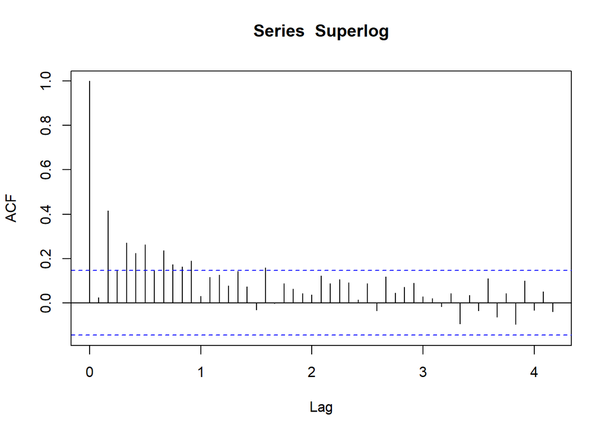

```r
acf(Superlog, 50)
```

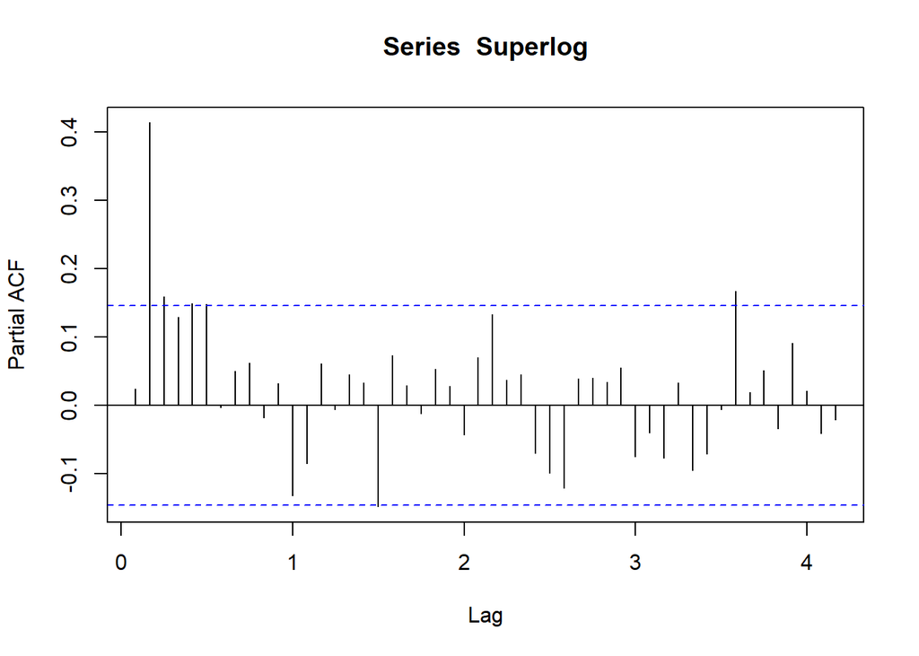

```r
pacf(Superlog, 50)
```

Reiteraremos la prueba de estacionalidad en la serie

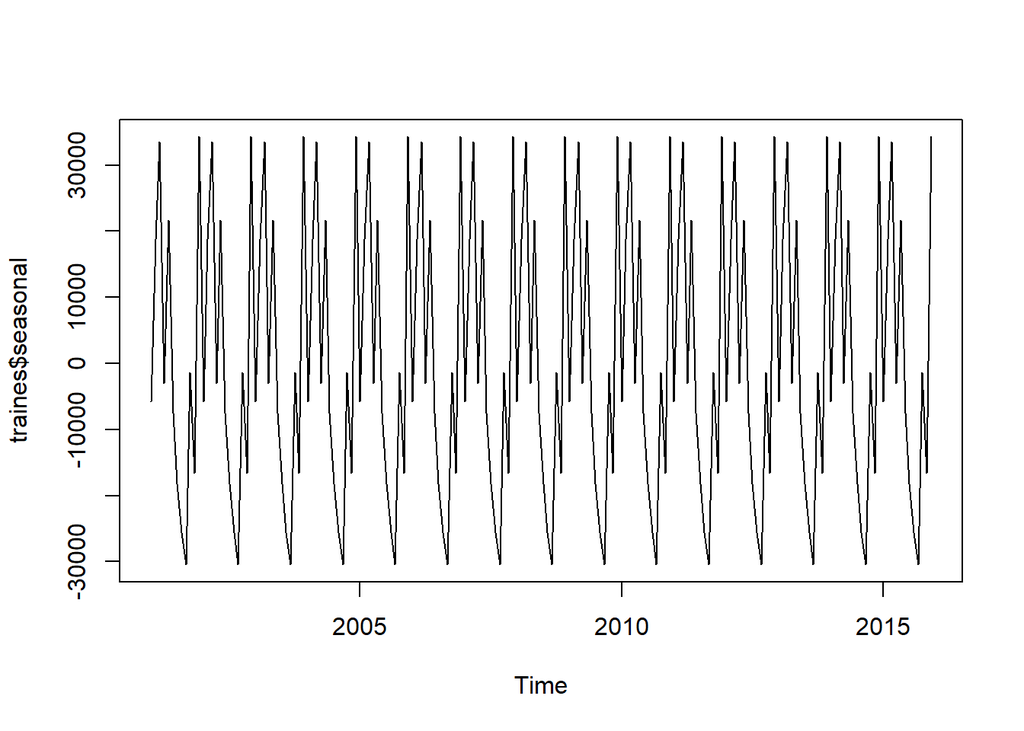

```r
traines <- decompose(train)
plot(traines$seasonal)
```

Si contiene estacionalidad, le aplicaremos 36 resagos para identificar los picos

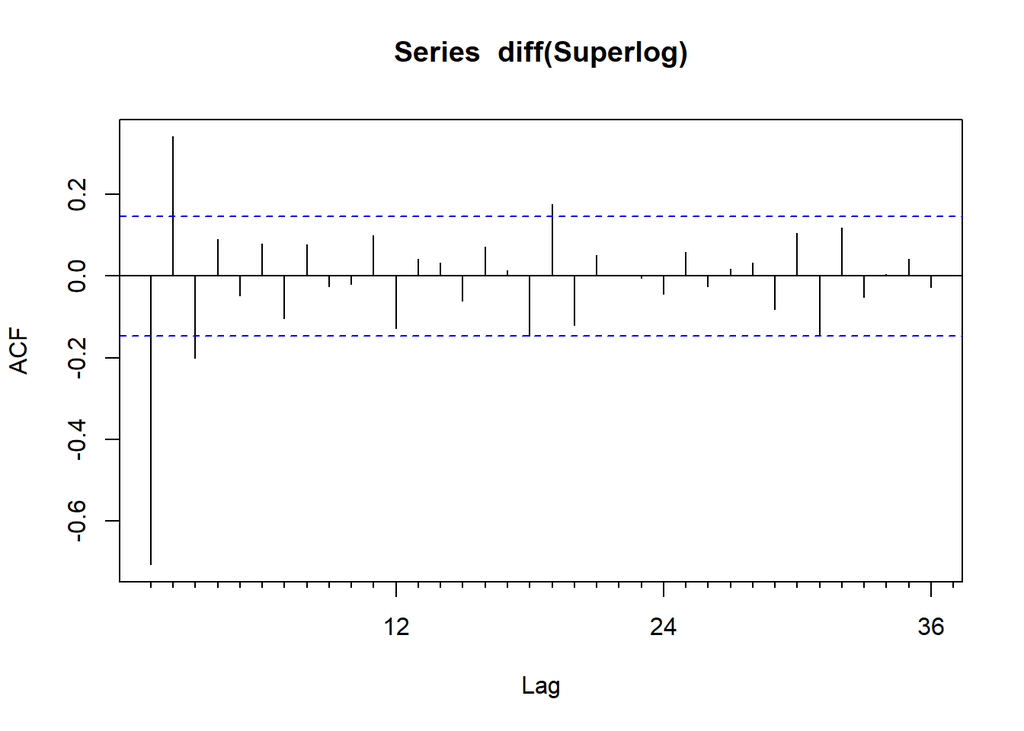

```r
Acf(diff(Superlog),36)
```

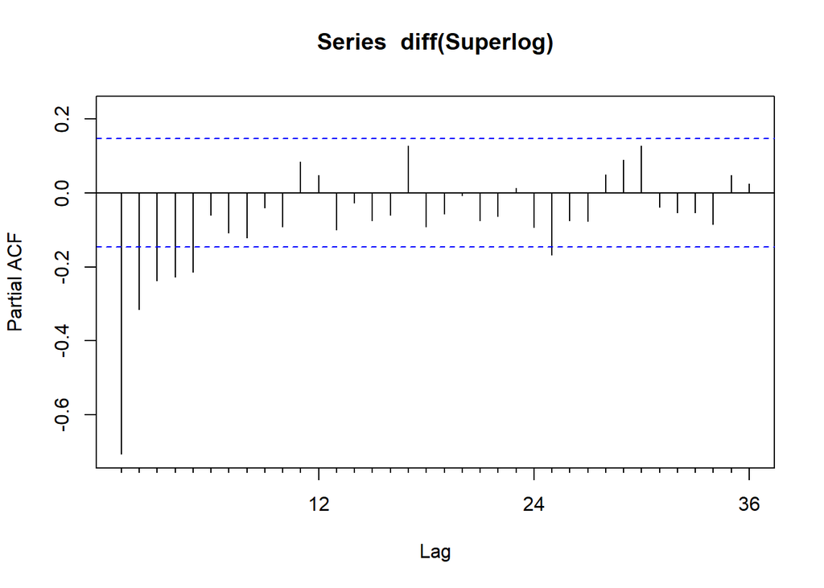

```r
Pacf(diff(Superlog),36)
```

```r
fitArima<-arima(Superlog, order = c(1,2,2), seasonal =c(1,1,0))
fautoarima<-auto.arima(train)
fautoarima
```

```
## Series: train
## ARIMA(1,1,2)(0,0,1)[12] with drift
##
## Coefficients:
##           ar1      ma1      ma2     sma1      drift
##       -0.6584  -0.5301  -0.2797  -0.1442  1508.1457
## s.e.   0.1417   0.1746   0.1646   0.0785   691.4512
##
## sigma^2 = 8.217e+09:  log likelihood = -2295.81
## AIC=4603.61   AICc=4604.1   BIC=4622.74
```

Para comprobar, haremos la validacion

```r
library(lmtest)
coeftest(fitArima)
```

```
##
## z test of coefficients:
##
##       Estimate Std. Error  z value  Pr(>|z|)
## ar1  -0.358355   0.075844  -4.7249 2.302e-06 ***
## ma1  -1.924154   0.039006 -49.3296 < 2.2e-16 ***
## ma2   0.928957   0.039892  23.2867 < 2.2e-16 ***
## sar1 -0.560163   0.063029  -8.8874 < 2.2e-16 ***
## ---
## Signif. codes:  0 '***' 0.001 '**' 0.01 '*' 0.05 '.' 0.1 ' ' 1
```

Ahora haremos el modelo generado por R, para comprobar los dos modelos.

```r
coeftest(fautoarima)
```

```
##
## z test of coefficients:
##
##          Estimate  Std. Error z value  Pr(>|z|)
## ar1     -0.658389    0.141670 -4.6474 3.362e-06 ***
## ma1     -0.530149    0.174573 -3.0368  0.002391 **
## ma2     -0.279659    0.164587 -1.6992  0.089291 .
## sma1    -0.144198    0.078535 -1.8361  0.066341 .
## drift 1508.145723  691.451189  2.1811  0.029174 *
## ---
## Signif. codes:  0 '***' 0.001 '**' 0.01 '*' 0.05 '.' 0.1 ' ' 1
```

## Prediccion

```r
auto.arima(super_ts)
```

```
## Series: super_ts
## ARIMA(2,1,1) with drift
##
## Coefficients:
##           ar1     ar2      ma1     drift
##       -0.0688  0.2359  -0.9503  1441.048
## s.e.   0.0695  0.0692   0.0294   444.551
##
## sigma^2 = 1.227e+10:  log likelihood = -3335.83
## AIC=6681.67   AICc=6681.91   BIC=6699.39
```

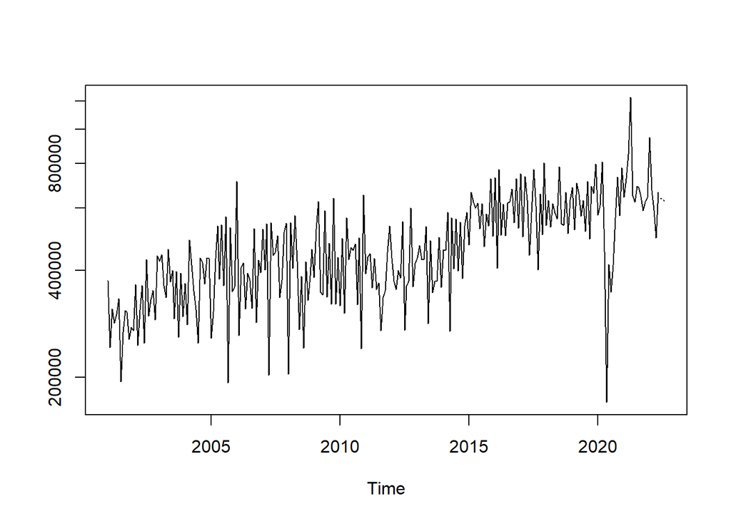

```r
fit <- arima(log(super_ts), c(0, 1, 1),seasonal = list(order = c(0, 1, 1), period = 12))
pred <- predict(fit, n.ahead = 3)
ts.plot(super_ts,2.718^pred$pred, log = "y", lty = c(1,3))
```

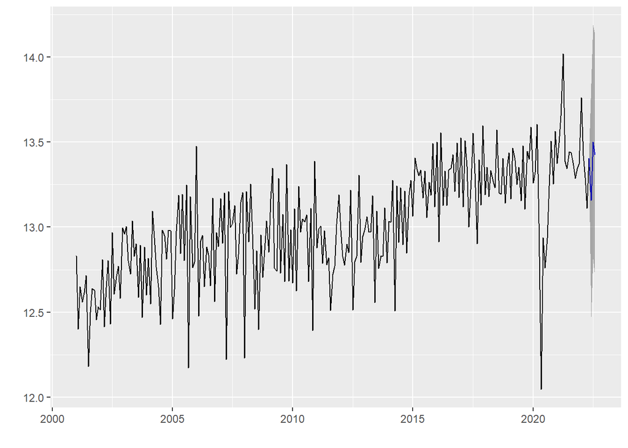

```r
fit2 <- arima(log(super_ts), c(2, 1, 1),seasonal = list(order = c(0, 1, 0), period = 12))



forecastAP <- forecast(fit2, level = c(95), h = 3)
autoplot(forecastAP)
```

## Combustible REGULAR:

```r
# Para el combustible Superior
regular_ts <- ts( regular$`Regular`, start = c(2001,1),frequency = 12)

# Inicio de la serie
start(regular_ts)
```

```
## [1] 2001    1
```

```r
#Final de la serie
end(regular_ts)
```

```
## [1] 2022    5
```

```r
#Frecuencia de la serie
frequency(regular_ts)
```

```
## [1] 12
```

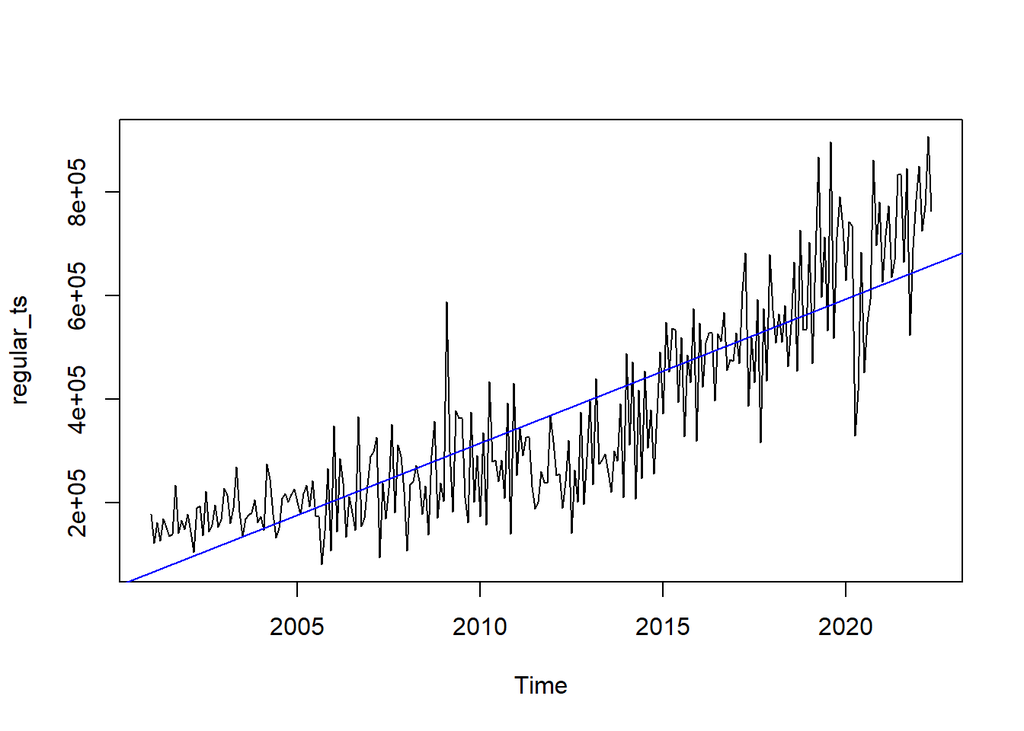

```r
#Resultado en forma de grafica.
plot(regular_ts)
abline(reg=lm(regular_ts~time(regular_ts)), col=c("blue"))
```

Con esto, podemos ver el compartamiento que ha tenido el combustible regular a lo largo de los años.

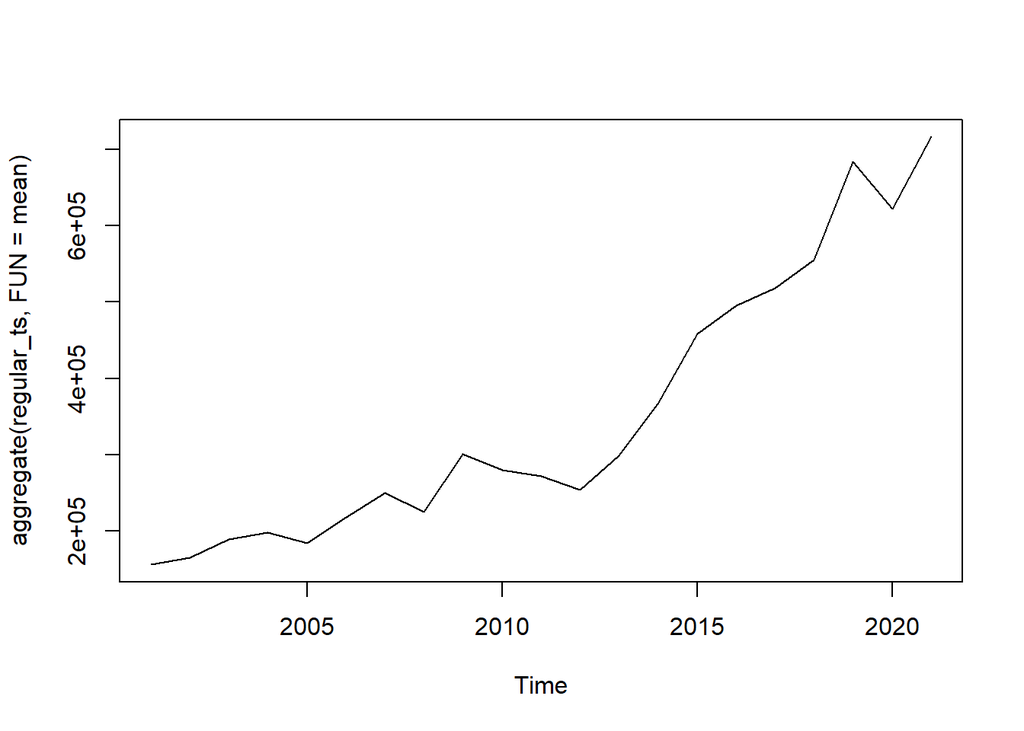

```r
plot(aggregate(regular_ts,FUN=mean))
```

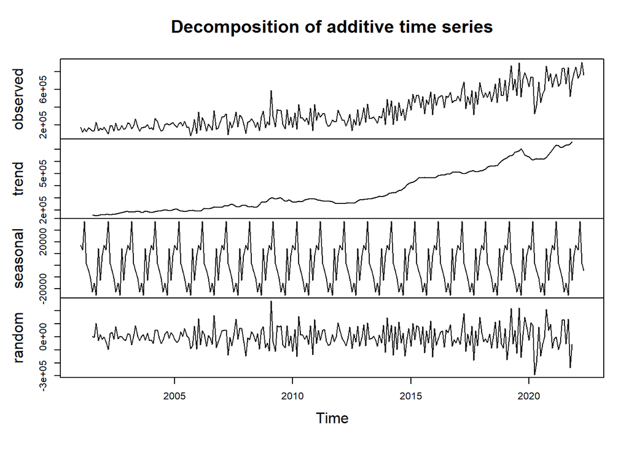

```r
dec.Regul<-decompose(regular_ts)
plot(dec.Regul)
```

Como se observa en la grafica anterior, la serie tiene tendencia a aumentar asi como que tambien tiene estacionalidad y por ultimo, se puede ver que no es estacionaria en varianza, por eso debemos aplicarle una transformacion logaritmica.

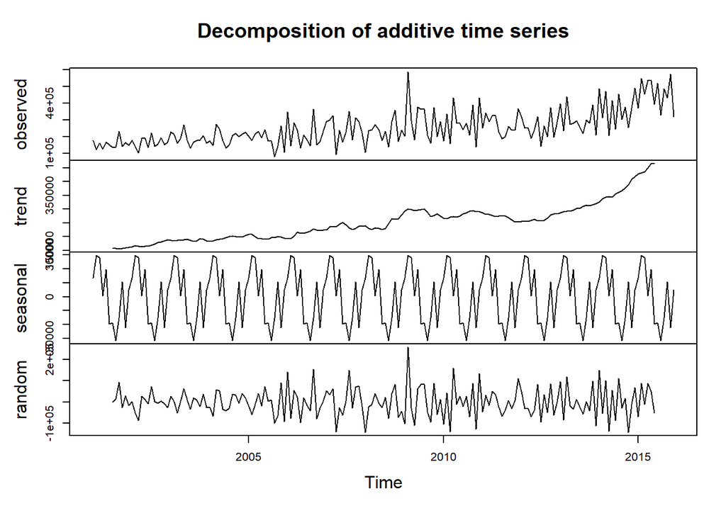

```r
train <- head(regular_ts, round(length(regular_ts) * 0.7))
h <- length(regular_ts) - length(train)
test <- tail(regular_ts, h)
#Aplicaremos una transformación logarítmica
Regulog <- log(train)
plot(decompose(train))
```

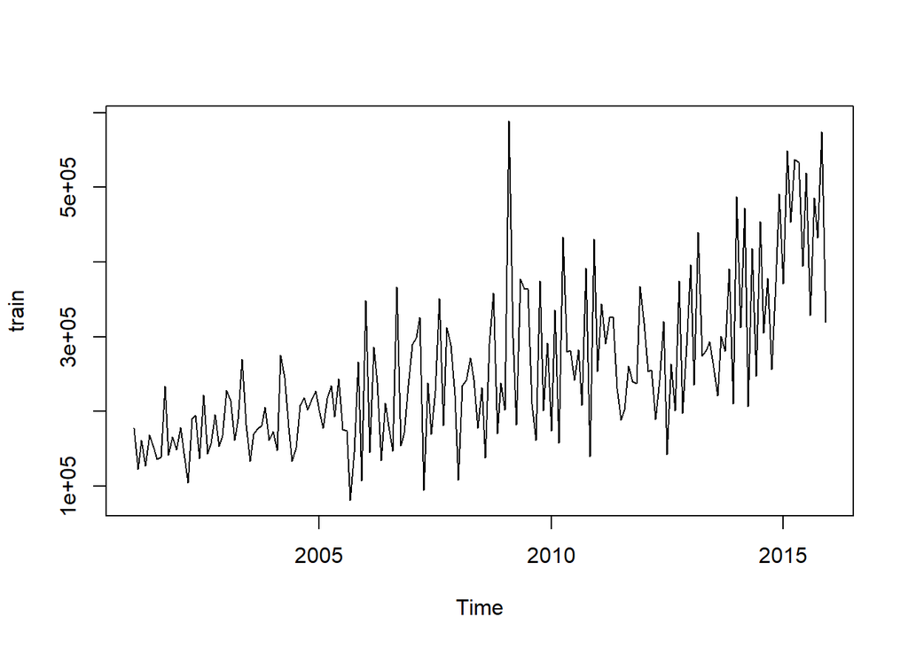

```r
#Ver el gráfico de la serie
plot(train)
```

Se observa con esta transformacion, se logro hacer constante en varianza, ahora podemos enfocarnos en su estacionalidad en la media, para eso haremos la prueba de raices…

```r
adfTest(train)
```

```
##
## Title:
##  Augmented Dickey-Fuller Test
##
## Test Results:
##   PARAMETER:
##     Lag Order: 1
##   STATISTIC:
##     Dickey-Fuller: -0.8286
##   P VALUE:
##     0.3507
##
## Description:
##  Sun Aug 07 23:24:20 2022 by user: Quezada
```

```r
unitrootTest(train)
```

```
##
## Title:
##  Augmented Dickey-Fuller Test
##
## Test Results:
##   PARAMETER:
##     Lag Order: 1
##   STATISTIC:
##     DF: -0.8286
##   P VALUE:
##     t: 0.3558
##     n: 0.5026
##
## Description:
##  Sun Aug 07 23:24:20 2022 by user: Quezada
```

El valor de P es mayor a 0.05, por lo que ahora veremos que pasa si le aplicamos una diferenciacion

```r
adfTest(diff(train))
```

```
##
## Title:
##  Augmented Dickey-Fuller Test
##
## Test Results:
##   PARAMETER:
##     Lag Order: 1
##   STATISTIC:
##     Dickey-Fuller: -15.6588
##   P VALUE:
##     0.01
##
## Description:
##  Sun Aug 07 23:24:20 2022 by user: Quezada
```

```r
unitrootTest(diff(train))
```

```
##
## Title:
##  Augmented Dickey-Fuller Test
##
## Test Results:
##   PARAMETER:
##     Lag Order: 1
##   STATISTIC:
##     DF: -15.6588
##   P VALUE:
##     t: < 2.2e-16
##     n: 0.005102
##
## Description:
##  Sun Aug 07 23:24:20 2022 by user: Quezada
```

Con el nuevo valor de P, que es menor a 0.5, podemos asumir que tenemos un valor D=1, por lo que ahora identificaremos el valor P y Q

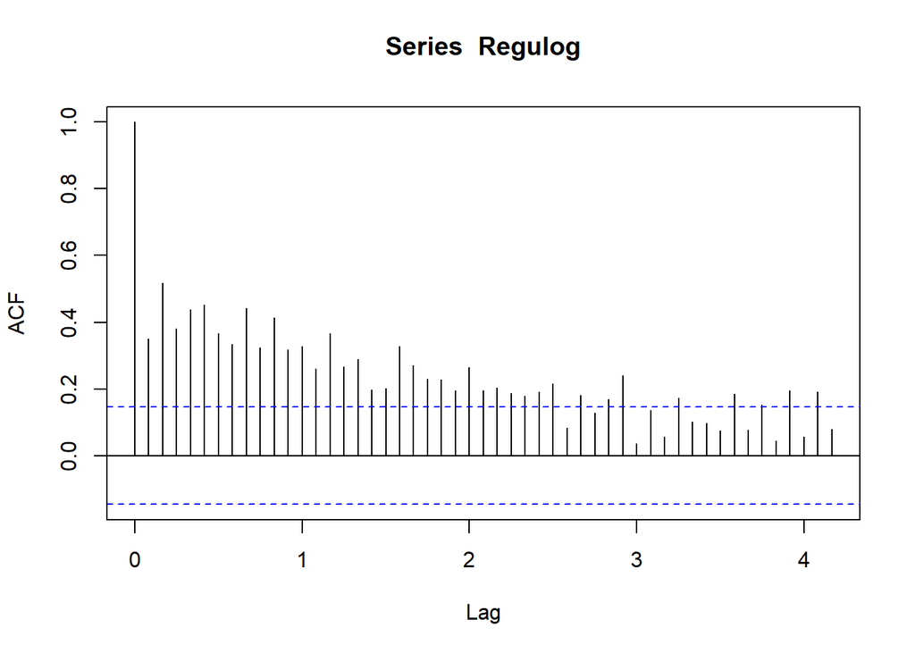

```r
acf(Regulog, 50)
```

Basandonos en la grafica, podemos asumir que el valor de Q sera igual a 2, ahora trataremos de identificar el valor de P.

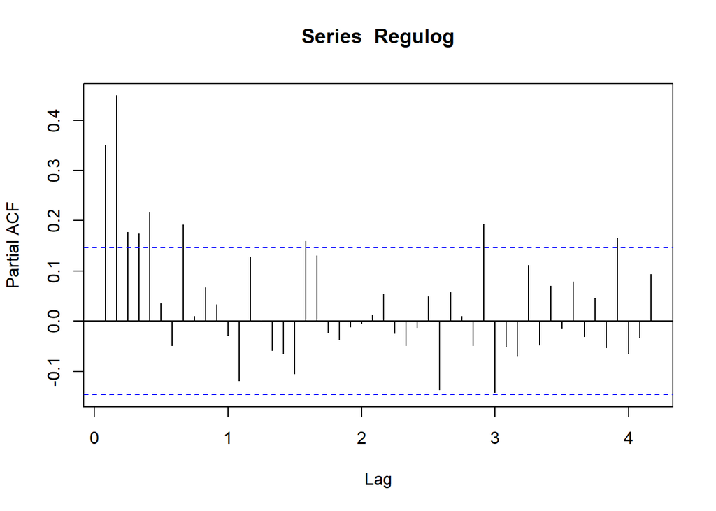

```r
pacf(Regulog, 50)
```

Igualmente, tomando en cuenta lo visto en la grafica, podemos pensar que el valor de P es igual a 2, es decir, trabajaremos con un modelo ARIMA de la siguiente manera:

P = 2 Q = 2 D = 1

Reiteraremos la prueba de estacionalidad en la serie

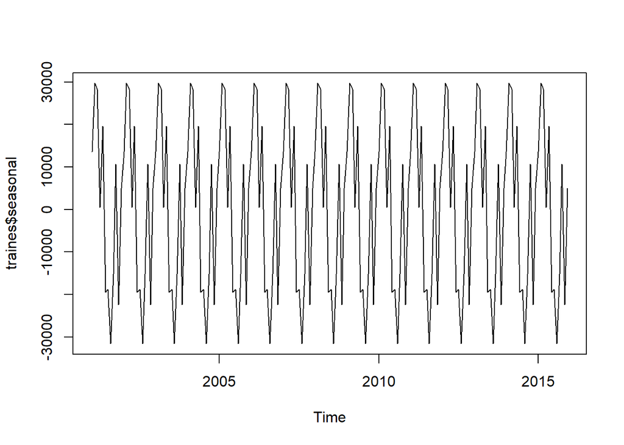

```r
traines <- decompose(train)
plot(traines$seasonal)
```

Si contiene estacionalidad, le aplicaremos 36 resagos para identificar los picos

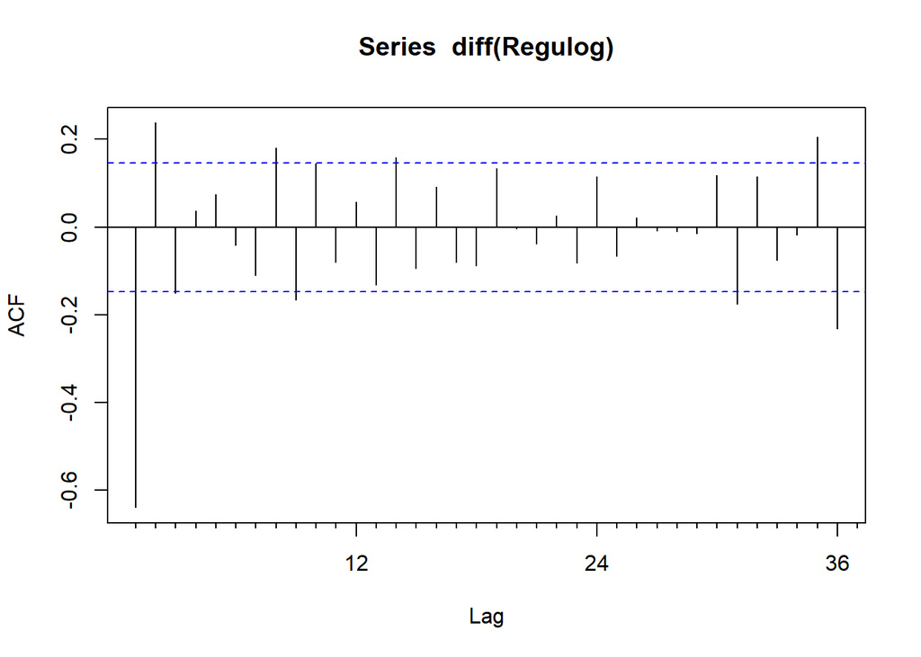

```r
Acf(diff(Regulog),36)
```

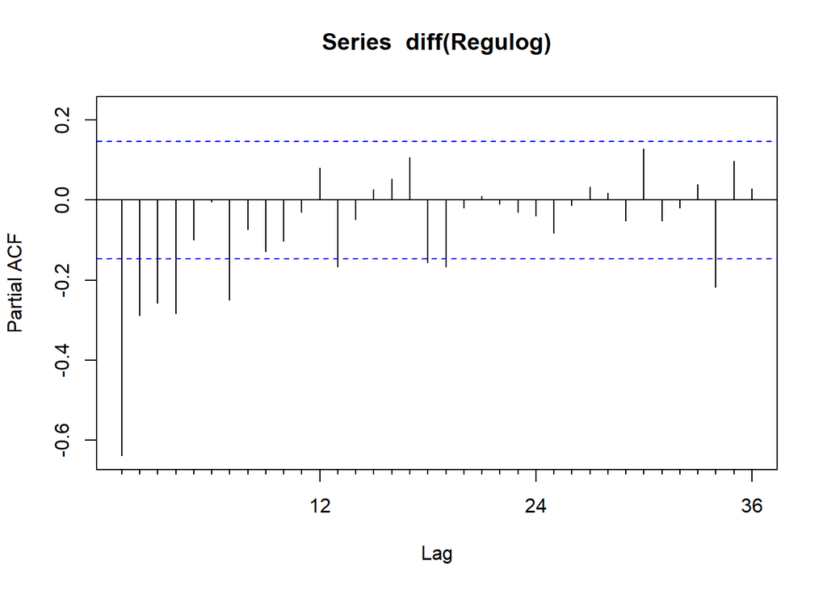

```r
Pacf(diff(Regulog),36)
```

```r
fitArima<-arima(Regulog, order = c(2,1,2), seasonal =c(1,1,0))
fautoarima<-auto.arima(train)
fautoarima
```

```
## Series: train
## ARIMA(1,1,2) with drift
##
## Coefficients:
##           ar1      ma1      ma2      drift
##       -0.7178  -0.3844  -0.4193  1687.0910
## s.e.   0.1504   0.1844   0.1733   662.6249
##
## sigma^2 = 5.681e+09:  log likelihood = -2263.07
## AIC=4536.14   AICc=4536.49   BIC=4552.08
```

Para comprobar, haremos la validacion

```r
library(lmtest)
coeftest(fitArima)
```

```
##
## z test of coefficients:
##
##       Estimate Std. Error  z value  Pr(>|z|)
## ar1   0.704323   0.107292   6.5645  5.22e-11 ***
## ar2   0.141409   0.084022   1.6830   0.09237 .
## ma1  -1.867175   0.079344 -23.5326 < 2.2e-16 ***
## ma2   0.888166   0.074460  11.9281 < 2.2e-16 ***
## sar1 -0.575268   0.063042  -9.1252 < 2.2e-16 ***
## ---
## Signif. codes:  0 '***' 0.001 '**' 0.01 '*' 0.05 '.' 0.1 ' ' 1
```

Ahora haremos el modelo generado por R, para comprobar los dos modelos.

```r
coeftest(fautoarima)
```

```
##
## z test of coefficients:
##
##         Estimate Std. Error z value  Pr(>|z|)
## ar1     -0.71775    0.15042 -4.7716 1.828e-06 ***
## ma1     -0.38435    0.18444 -2.0839   0.03717 *
## ma2     -0.41932    0.17328 -2.4199   0.01552 *
## drift 1687.09099  662.62487  2.5461   0.01089 *
## ---
## Signif. codes:  0 '***' 0.001 '**' 0.01 '*' 0.05 '.' 0.1 ' ' 1
```

## Prediccion

```r
auto.arima(regular_ts)
```

```
## Series: regular_ts
## ARIMA(1,1,2) with drift
##
## Coefficients:
##           ar1      ma1      ma2      drift
##       -0.6549  -0.4036  -0.4047  2471.4522
## s.e.   0.1775   0.2046   0.1902   659.6801
##
## sigma^2 = 7.977e+09:  log likelihood = -3280.47
## AIC=6570.94   AICc=6571.18   BIC=6588.67
```

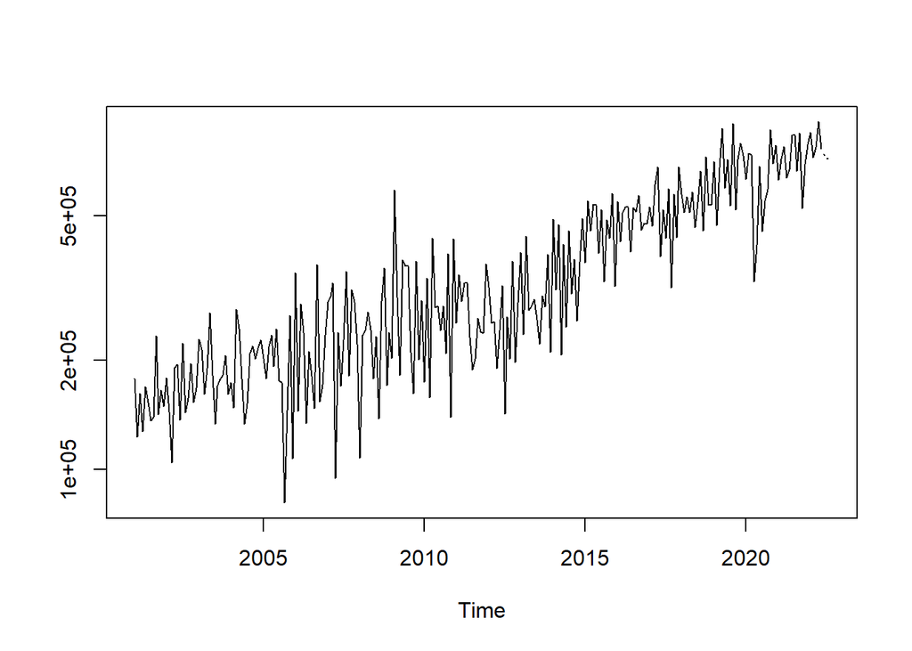

```r
fit <- arima(log(regular_ts), c(0, 1, 1),seasonal = list(order = c(0, 1, 1), period = 12))
pred <- predict(fit, n.ahead = 3)
ts.plot(regular_ts,2.718^pred$pred, log = "y", lty = c(1,3))
```

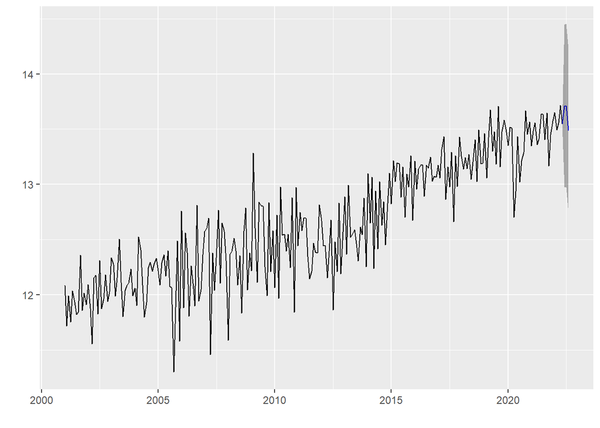

```r
fit2 <- arima(log(regular_ts), c(2, 1, 1),seasonal = list(order = c(0, 1, 0), period = 12))



forecastAP <- forecast(fit2, level = c(95), h = 3)
autoplot(forecastAP)
```